# Why people like Komoot in the USA

Text Analysis based on 157 user reviews in US App Store

[figure not shown]

## Introduction

This report is a part of my job application for Data Analyst position at Komoot. The job description is here: http://https://www.komoot.com/jobs/data-analyst). This is report is the “Doing something creative with komoot” part.

## What I did

1. I scraped 157 app reviews from US App Store (by a simple node.js script)
2. I did some exploratory data analysis
3. I did sentiment analysis. What feelings and emotions are related to a review?
4. I reviewed the reason about good and bad ratings
5. I created a basic prediction for rating based on review texts
6. Make recommendations on how to improve user satisfaction in the US

## Actionable insights

Overall recommendations based on this super small dataset:

1. Increase the penetration in other countries (like France, UK, Canada and the USA)
2. Improve user experience
3. Improve battery usage
4. Now iTunes supports response for feedbacks. Allocate resource to respond and evaluate latest feedbacks to turn them to action points

Please review the rest of report for explanations.

## Data import

The node.js script scraped the reviews in JSON format. It was fixed manually first. After that, I imported it by jsonlite library in R.

```r
# Data import and cleaning ------------------------------------------------

# Read US App Store reviews about Komoot
reviews <- read_json("reviews.json")

# Translate to tibble
reviews <-  bind_rows(reviews)

reviews
```

| id | userName | userUrl | version | score | title | text | url |
| --- | --- | --- | --- | --- | --- | --- | --- |
| 2575912510 | Fletchy71 | https://itunes.apple.com/us/reviews/id30470133 | 9.8.1 | 5 | Great Combo with Elemnt Bolt | Used it twice for two 75km rides in Denmark, including sections of single track, as well as 32km MTB ride through single track. \n\nAt first, it seemed to simple when compared to RideWithGPS. My first… | https://itunes.apple.com/us/review?id=447374873&type=Purple%20Software |
| 2587568538 | sgt. bonghits | https://itunes.apple.com/us/reviews/id40219409 | 9.8.1 | 5 | Love Komoot!! | I couldn’t happier with Komoot! Personal route setup is super easy! It will sync to my Wahoo Bolt in seconds. Do it! You know you want to now!! | https://itunes.apple.com/us/review?id=447374873&type=Purple%20Software |
| 2603770852 | Architect84 | https://itunes.apple.com/us/reviews/id111200796 | 9.7.1 | 5 | Great App | Very enjoyable and useful! | https://itunes.apple.com/us/review?id=447374873&type=Purple%20Software |
| 2613823452 | Mihaltanvicu | https://itunes.apple.com/us/reviews/id249412574 | 9.8.1 | 5 | Vick | I love this App. I can take pictures, save the the map, very easy to use. Thank you. | https://itunes.apple.com/us/review?id=447374873&type=Purple%20Software |
| 2628090313 | njgym | https://itunes.apple.com/us/reviews/id217312944 | 9.8.1 | 2 | Not ready for prime time | Based on routes proposed on local roads well known, this is no better than Google at recommending a really rideable route. 2 stars as an attaboy only. | https://itunes.apple.com/us/review?id=447374873&type=Purple%20Software |
| 2661985777 | Giovanni xmilkcratex | https://itunes.apple.com/us/reviews/id48770805 | 9.8.2 | 4 | Love after first ride | I tested and trusted the komoot for the first time on overnight bike tour through the Catskills and had an excellent time. \n\nPersonally, I think the interface is really easy to use and better to edi… | https://itunes.apple.com/us/review?id=447374873&type=Purple%20Software |
| 2668047030 | jduprey | https://itunes.apple.com/us/reviews/id37255874 | 9.8.2 | 5 | Solid app that lets you ride with confidence | Plan a route or add one shared with you via GPX or similar format. This app works well. Best of all is I don’t have to pay a subscription!!! Please share this app with others and let them know it exis… | https://itunes.apple.com/us/review?id=447374873&type=Purple%20Software |
| 1797177215 | Ralph8540 | https://itunes.apple.com/us/reviews/id221349708 | 9.3.1 | 5 | Two Trips, Two Winners | Just started using the app. So far I"ve done one hike and one tandem bike ride. The app has worked flawlessly both times and I really like the way it interfaces with Apple Heart and Facebook. Will put… | https://itunes.apple.com/us/review?id=447374873&type=Purple%20Software |
| 1950642628 | GlobalCreations | https://itunes.apple.com/us/reviews/id35856208 | 9.5.1 | 5 | Been Using It For Years | Just got an iPhone X and Komoot still works perfectly. I used around 80% of the battery in around 5 hours while also using Avenza Maps off and on. I carry a battery pack because these types of apps do… | https://itunes.apple.com/us/review?id=447374873&type=Purple%20Software |
| 2012919135 | Nycgaffer | https://itunes.apple.com/us/reviews/id86075773 | 9.6.1 | 3 | Promising app with flaws | I like this app and hope they work out some of the kinks.\nThe first problem is that I have not been able to sync my wahoo cadence sensor, speed sensor or powercal powertap. Sent a query to tech suppo… | https://itunes.apple.com/us/review?id=447374873&type=Purple%20Software |

[output cut: 147 more lines]

## Let’ explore the data

The iTunes shows 4.2 average rating in the USA. Let’s check that by calculate mean of all score points. It seems the same.

```r
# Average ratings of Komoot App in the US Store based on these 157 reviews
mean(reviews$score)
```

```
## [1] 4.216561
```

What are the distributions of the ratings?

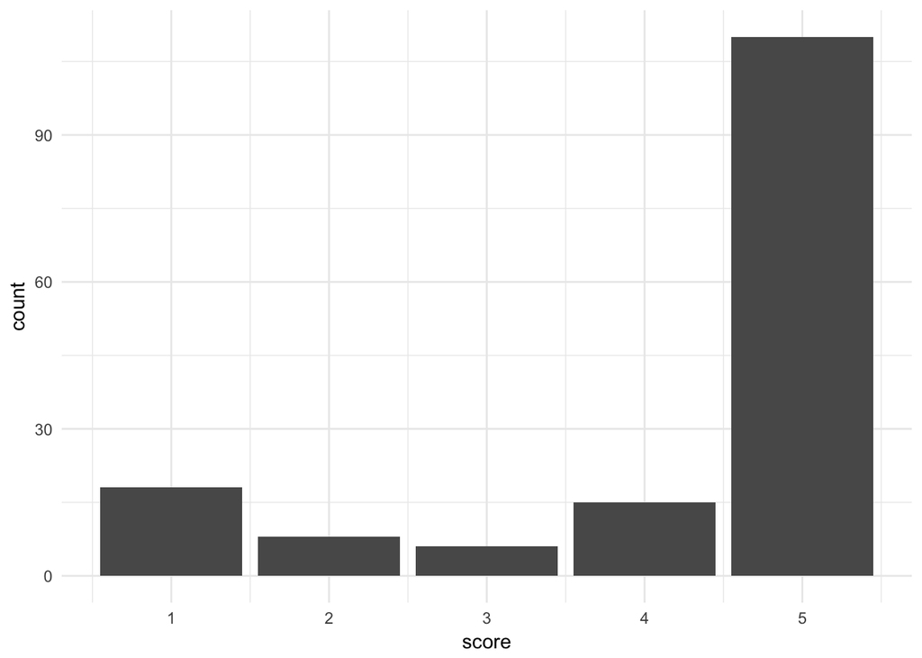

```r
# Distributions of ratings
reviews %>%  ggplot(aes(score)) + geom_bar() + theme_minimal()
```

It seems most of the ratings are 5 stars. The second biggest number is the 1, the third is the 4 scores. We will dive into the deep in a later section what the most relevant reason by giving 5 or 1 star. y Now let’s check what is the distribution of comment numbers by app version.

```r
version_counts %>% head()
```

| version | Count |
| --- | --- |
| 9.1.2 | 26 |
| 8.2 | 13 |
| 9.3.1 | 11 |
| 8.0 | 9 |
| 9.0.1 | 7 |
| 9.7.1 | 7 |

Now, look at the average ratings by version.

Which was the best?

```r
reviews %>% select(version, score) %>% group_by(version) %>% summarise(Mean=mean(score)) %>% arrange(desc(Mean))
```

| version | Mean |
| --- | --- |
| 2.5 | 5.000000 |
| 6.5 | 5.000000 |
| 6.5.2 | 5.000000 |
| 6.6 | 5.000000 |
| 6.7 | 5.000000 |
| 6.7.1 | 5.000000 |
| 7.0 | 5.000000 |
| 7.2 | 5.000000 |
| 8.3.1 | 5.000000 |
| 8.4 | 5.000000 |

[output cut: 32 more lines]

Oops. It seems that those versions which get only 1 rating and got 5 are the best. This is not representative of course. The solution is to calculate the weighted mean (mean x number of reviews).

```r
reviews %>% select(version, score) %>% group_by(version) %>% summarise(Mean=mean(score), Count=n()) %>% mutate(weighted.mean=Mean*Count) %>%  arrange(desc(weighted.mean))
```

| version | Mean | Count | weighted.mean |
| --- | --- | --- | --- |
| 9.1.2 | 4.384615 | 26 | 114 |
| 8.2 | 4.615385 | 13 | 60 |
| 9.3.1 | 4.454545 | 11 | 49 |
| 9.0.1 | 4.857143 | 7 | 34 |
| 9.1.1 | 4.666667 | 6 | 28 |
| 8.5.1 | 4.500000 | 6 | 27 |
| 9.7.1 | 3.714286 | 7 | 26 |
| 9.8.1 | 4.333333 | 6 | 26 |
| 9.0 | 5.000000 | 5 | 25 |
| 8.0.1 | 3.833333 | 6 | 23 |

[output cut: 32 more lines]

## What is the reason why people like komoot?

To get the most relevant information let’s review the word frequencies in 5-star reviews. The most frequent words in best ratings are:

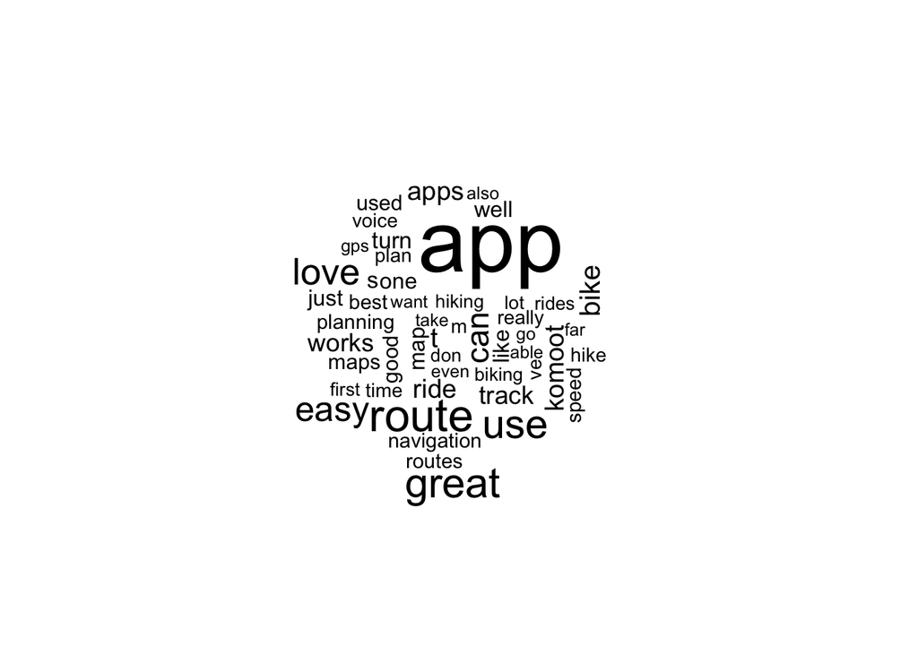

```r
reviews %>%
  select(score, text) %>%
  filter(score==5) %>%
  tidytext::unnest_tokens(word, text, token = "words") %>%
  anti_join(get_stopwords()) %>%
  count(word, sort=T) %>%
  with(wordcloud(word, n, max.words = 50))
```

There are a lot of positive words like “easy”, “great”, “love” etc. In the next section, we will connect sentiments to the reviews to understand how users feel. Until then check the words frequency in 1-star reviews.

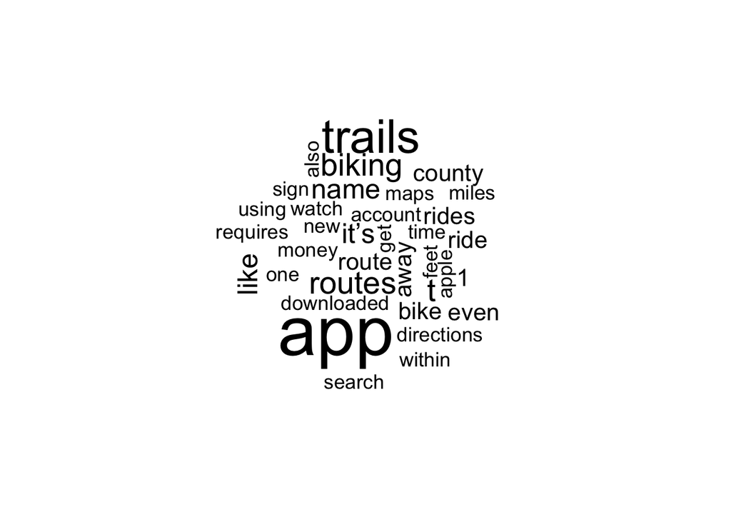

```r
reviews %>%
  select(score, text) %>%
  filter(score==1) %>%
  tidytext::unnest_tokens(word, text, token = "words") %>%
  anti_join(get_stopwords()) %>%
  count(word, sort=T) %>%
  with(wordcloud(word, n, max.words = 50))
```

The positive words are disappeared, but it does not help us to understand what is the biggest problem with the app. To see the issues we need to dive into the sentiment analysis.

## Sentiment analysis

Sentiment analysis is opinion mining (sometimes known as emotion AI) related to natural language processing. The goal is to identify, extract, quantify, and study affective states and subjective information.

Let’s review the relevant feelings in all of the text reviews. Here I count the most frequent words.

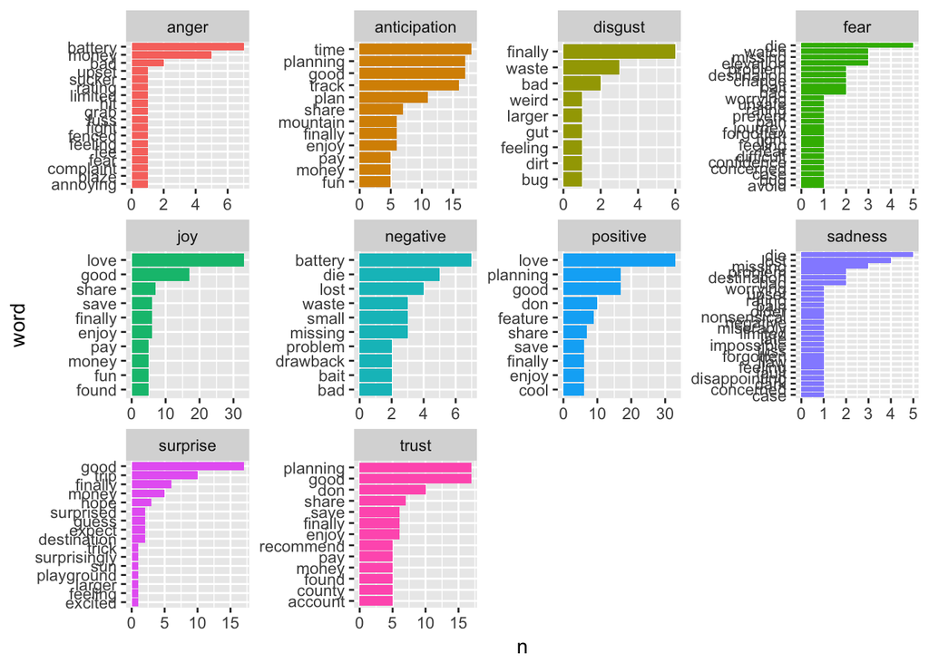

```r
word_data <- reviews %>%
  select(userName, text) %>%
  tidytext::unnest_tokens(word, text, token = "words")

# Get nrc sentiment lexicon
nrc <- get_sentiments("nrc")
sentiments <- word_data %>% inner_join(nrc) %>% left_join(y=reviews[,c("userName", "score")])


# Which words are relevant to specific sentiments
sentiments %>%
  # Count by word and sentiment
  count(word, sentiment) %>%
  # Group by sentiment
  group_by(sentiment) %>%
  # Take the top 10 words for each sentiment
  top_n(10) %>%
  ungroup() %>%
  mutate(word = reorder(word, n)) %>%
  # Set up the plot with aes()
  ggplot(aes(word, n, fill=sentiment)) +
  geom_col(show.legend = FALSE) +
  facet_wrap(~ sentiment, scales = "free") +
  coord_flip()
```

Let’s review the negative sentiments: anger, disgust, fear, negative, sadness.

The biggest negative words are related to “battery” and “die”. Let’s filter the review texts include these words.

```r
reviews %>%
  select(text) %>%
  filter(grepl("battery", text) | grepl("die", text) )
```

| text |
| --- |
| Just started using the app. So far I"ve done one hike and one tandem bike ride. The app has worked flawlessly both times and I really like the way it interfaces with Apple Heart and Facebook. Will put… |
| Just got an iPhone X and Komoot still works perfectly. I used around 80% of the battery in around 5 hours while also using Avenza Maps off and on. I carry a battery pack because these types of apps do… |
| Komoot is a great app for planning, pictures and sharing. I shared a two-week hiking trip around Mont Blanc with all of my friends and Komoot made it easy and convenient. My one complaint is that I wi… |
| Works great for bike touring. Uses less battery life than google maps and works great, even when in airplane mode. Tracks your progress, giving you mileage as you go, and average speed, etc. |
| Komoot has shown me the best roads, trails & more around the world. I"ll die having seen more awesomeness in my lifetime thanks to this app! |
| App funktioniert fürs Rennrad sehr gut. Neue Touren lassen sich einfach planen und die Sprachausgabe gibt die richtigen Anweisungen. Wenn man die Navigation startet und nicht gleich losfährt mein Komo… |
| Ich habe dieses App erst heute benutzt und bin total überrascht. Sehr schönes App. Respekt!!! |
| Ich habe es über das Wochenende benutzt und fand die Ratschläge in Ordnung. Bei Radtour werde ich das öfters benutzen. |

Let’s check the most positive and frequent word “love” in review texts.

```r
reviews %>%
  select(text) %>%
  filter(grepl("love", text))
```

| text |
| --- |
| I love this App. I can take pictures, save the the map, very easy to use. Thank you. |
| I tested and trusted the komoot for the first time on overnight bike tour through the Catskills and had an excellent time. \n\nPersonally, I think the interface is really easy to use and better to edi… |
| This app has great potential but it’s nearly impossible to put in a running route because it forces a round trip or with one way won’t allow a return to the beginning. I’d love to use to map out route… |
| So good. I love that it tracks your route. I haven"t had any issues. It is only my first use, though. |
| Grate app love it use it all the time |
| I love the quality and attention to detail that this app offers. It"s the only alternative to Google Maps that I actually enjoy using. \n\nPros:\n--> Road surface analysis and choices in planning rout… |
| This app is really great. I love being able to plan and track my hikes. It organizes every outing that I take now, and remembers which pictures I took on which trails.\n\nIf you are at all inclined to… |
| Komoot was recommended to me while on a cycling trip to Spain. I have to say that I love this app. Gives me all the information that I need, offers multiple route options, and also speaks out the dire… |
| I love how easy it is to use and it incorporates photos you"ve taken from your recorded exercise. It"s also fun to be able to tag others on the same trip. |
| Great app to have with you to plan a hike or a mountain bike ride. I love the suggestions it generates and it makes it easy to plan a weekend hike. I wish the app had the ability to import GPS track f… |

[output cut: 10 more lines]

People generally love the app because:

- Ability of planning and tracking routes
- Displaying suggestions and showing elevation
- Tagging others
- Sharing features

Note that these reviews are not purely positive. Some of them contain recommendations for user experience and trip planning too.

## Machine learning demo: Predicting ratings by review text

Let’s try to predict ratings based on texts.

First I had to create a sparse matrix to represents word counts by users. Let’s review how it looks like. This is an excerpt which includes only 3 words: fun, bike and app. The userName and score columns are from the original table.

```r
sparse_matrix <- reviews %>%
  select(userName, text) %>%
  tidytext::unnest_tokens(word, text, token = "words") %>%
  anti_join(get_stopwords()) %>%
  count(userName, word, sort = TRUE) %>%
  cast_sparse(userName, word, n)

sparse_matrix <- as.data.frame(as.matrix(sparse_matrix))

sparse_matrix$userName <- rownames(sparse_matrix)

train_df <- left_join(x=sparse_matrix, y=reviews[,c("userName", "score")])

train_df %>% select(userName, score, fun, bike, app) %>% as_tibble()
```

| userName | score | fun | bike | app |
| --- | --- | --- | --- | --- |
| Fletchy71 | 5 | 0 | 0 | 1 |
| Biking is fun | 5 | 0 | 1 | 3 |
| zabadu | 1 | 0 | 0 | 0 |
| Giovanni xmilkcratex | 4 | 0 | 4 | 1 |
| ut bike rider | 5 | 0 | 0 | 2 |
| Chuckji | 3 | 0 | 1 | 2 |
| MusicDreamer101 | 5 | 0 | 0 | 4 |
| Oil intern | 1 | 0 | 0 | 4 |
| Pazuzu1991 | 5 | 0 | 0 | 0 |
| riffraf | 2 | 0 | 3 | 4 |

[output cut: 147 more lines]

Using H2O I tried the first Gradient Boosting Machine because we approximate a 1-5 scale. It could be also a multiclass classification. After that, by checking AutoML I found the best algorithm which is the Extreme Randomized Tree. I divided the dataset to train and test (75% - 25%). Check out the prediction results with XRT algorithm.

```r
h2o.performance(model_automl@leader, newdata = h_test)
```

```
## H2ORegressionMetrics: drf
##
## MSE:  1.004669
## RMSE:  1.002332
## MAE:  0.5455729
## RMSLE:  0.2659969
## Mean Residual Deviance :  1.004669
```

```r
h2o.no_progress()
new <- NULL
new$pred <- as.vector(h2o.predict(model_automl@leader, newdata = h_test))
new$actual <- as_data_frame(h_test)$score

as_data_frame(new) %>% head(n=20)
```

| pred | actual |
| --- | --- |
| 3.583333 | 1 |
| 4.875000 | 5 |
| 4.875000 | 5 |
| 5.000000 | 5 |
| 4.875000 | 5 |
| 5.000000 | 4 |
| 4.625000 | 3 |
| 5.000000 | 5 |
| 4.625000 | 5 |
| 5.000000 | 5 |

[output cut: 10 more lines]

After reviewing the results I found that the values are overpredicted because the values are imbalanced by rating 5.

## Future improvements in this text analysis

1. Review more sentiment related texts to understand more deeply user satisfaction/unsatisfaction
2. Involve other English reviews to extend the data set
3. Analyze german reviews with german lexicons
4. Balance the rating data to get the prediction

## Final words

Thank you to reading my report. If you have any question you can reach me at arpad.tot@gmail.com Moreover, I would be very happy to have skype/hangout call to discuss the position.

Thanks again, Arpad Toth